# Multiple Regression Analysis: Maryland Voter Turnout

# Introduction

Multiple regression analysis is a statistical method used to understand the relationship between one dependent variable and two or more independent variables. This analysis is particularly useful in journalism for exploring complex relationships in civic data, such as how different demographic and socioeconomic factors collectively impact voter turnout. By understanding these relationships, journalists can provide deeper insights into civic participation patterns and identify potential barriers to voting.

```r
library(tidyverse)
```

```r
#install.packages('corrplot')
library(corrplot)
```

## Load the Data

The first step in our analysis is to load the data. Here we read the data from a CSV file, which contains information about voter turnout and various demographic factors across Maryland counties. This dataset will be used to build our model that will try to see which factors are most important in predicting voter turnout. The turnout percentage is from the 2024 general election.

```r
md_turnout <- read_csv("https://raw.githubusercontent.com/dwillis/jour405/refs/heads/main/data/md_turnout.csv")
head(md_turnout)
```

```
## # A tibble: 6 × 9
##   geoid county     turnout population income pct_bachelors_higher pct_unemployed
##   <dbl> <chr>        <dbl>      <dbl>  <dbl>                <dbl>          <dbl>
## 1 24001 Allegany      0.75      67762  57393                0.149         0.0237
## 2 24003 Anne Arun…    0.76     590936 120324                0.315         0.0211
## 3 24005 Baltimore…    0.72     849586  90904                0.287         0.0266
## 4 24009 Calvert       0.78      93791 132059                0.243         0.0154
## 5 24011 Caroline      0.74      33406  66368                0.120         0.0269
## 6 24013 Carroll       0.8      174318 115876                0.277         0.0173
## # ℹ 2 more variables: median_age <dbl>, pct_white <dbl>
```

## Task 1: Exploratory Data Analysis (5 points)

Before building our model, let’s explore the data to understand the variables and their relationships. Examine the correlation matrix to see how the independent variables relate to each other and to the dependent variable (voter turnout). Which variables seem to be correlated? Are there any that are not correlated at all? Also look at the multiple scatterplots. Which variables seem to have a linear relationship with the dependent variable? Which do not?

pct_unemployed is the strongest correlate of turnout at -0.74 — that’s the biggest circle on the corrplot and it’s not close. pct_white comes in second at 0.69, median_age third at 0.50, income fourth at 0.45. pct_bachelors_higher (0.30) and population (-0.39) are the weakest of the group. The scatterplots back this up: pct_unemployed has a steep, clean negative trend, pct_white has a clear positive one, and median_age tracks fairly linearly. Income trends positive but with more scatter, and population is mostly flat until the two big urban outliers drag the line down.

The collinearity concern is real but it’s not between income and pct_unemployed — it’s between income and pct_bachelors_higher, which correlate at 0.75. Those two are measuring too much of the same thing. I’d be skeptical of running both in the same model.

```r
# Summary statistics
summary(md_turnout)
```

```
##      geoid             county      turnout         population
##  Min.   :24001   Length   :24   Min.   :0.5800   Min.   :  19265
##  1st Qu.:24014   N.unique :24   1st Qu.:0.7275   1st Qu.:  47640
##  Median :24026   N.blank  : 0   Median :0.7600   Median : 109369
##  Mean   :24045   Min.nchar: 4   Mean   :0.7450   Mean   : 257114
##  3rd Qu.:24038   Max.nchar:16   3rd Qu.:0.7725   3rd Qu.: 293735
##  Max.   :24510                  Max.   :0.8000   Max.   :1057586
##      income       pct_bachelors_higher pct_unemployed      median_age
##  Min.   : 52462   Min.   :0.1180       Min.   :0.01422   Min.   :36.10
##  1st Qu.: 71904   1st Qu.:0.1846       1st Qu.:0.01985   1st Qu.:38.88
##  Median : 91025   Median :0.2480       Median :0.02286   Median :40.30
##  Mean   : 94152   Mean   :0.2440       Mean   :0.02360   Mean   :41.42
##  3rd Qu.:116988   3rd Qu.:0.2793       3rd Qu.:0.02673   3rd Qu.:42.25
##  Max.   :146982   Max.   :0.4390       Max.   :0.03556   Max.   :51.10
##    pct_white
##  Min.   :0.1316
##  1st Qu.:0.5361
##  Median :0.7322
##  Mean   :0.6573
##  3rd Qu.:0.7819
##  Max.   :0.9547
```

```r
# Create correlation matrix
selected_vars <- md_turnout |>
  select(turnout, population, income, pct_bachelors_higher,
         pct_unemployed, median_age, pct_white)
correlation_matrix <- cor(selected_vars)
print(correlation_matrix)
```

```
##                         turnout population     income pct_bachelors_higher
## turnout               1.0000000 -0.3870512  0.4493372            0.3028735
## population           -0.3870512  1.0000000  0.3379372            0.5398245
## income                0.4493372  0.3379372  1.0000000            0.7520544
## pct_bachelors_higher  0.3028735  0.5398245  0.7520544            1.0000000
## pct_unemployed       -0.7393991  0.4112673 -0.3219080           -0.2161469
## median_age            0.4954073 -0.4031595 -0.2095238            0.0385520
## pct_white             0.6932347 -0.6777275 -0.1200588           -0.2196137
##                      pct_unemployed median_age  pct_white
## turnout                  -0.7393991  0.4954073  0.6932347
## population                0.4112673 -0.4031595 -0.6777275
## income                   -0.3219080 -0.2095238 -0.1200588
## pct_bachelors_higher     -0.2161469  0.0385520 -0.2196137
## pct_unemployed            1.0000000 -0.2956624 -0.5893534
## median_age               -0.2956624  1.0000000  0.5343044
## pct_white                -0.5893534  0.5343044  1.0000000
```

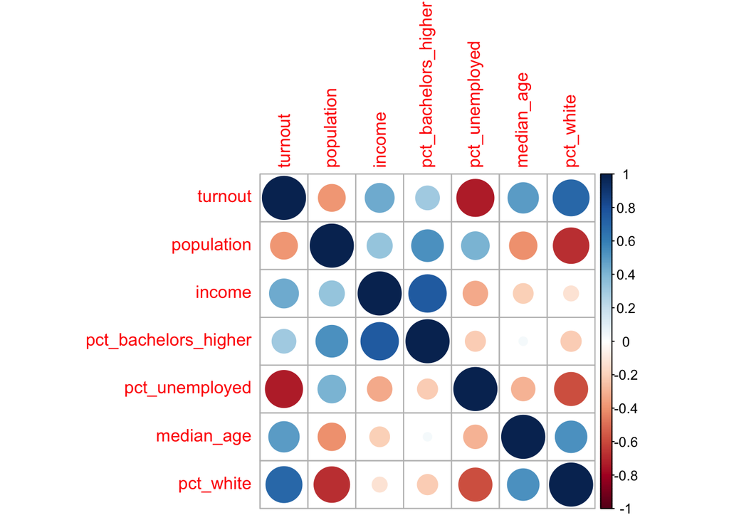

```r
# Visualize correlation matrix
corrplot(correlation_matrix, method = "circle")
```

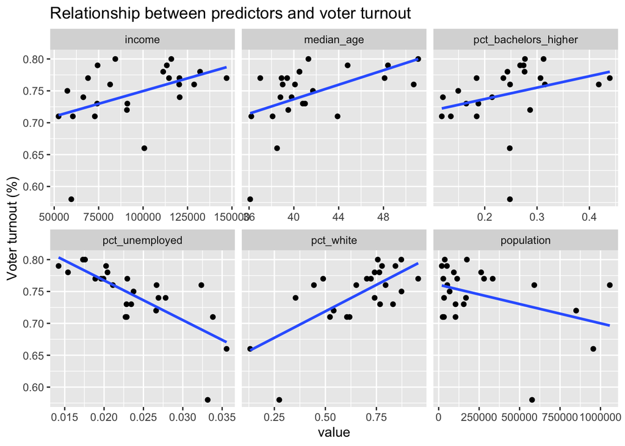

```r
# Create scatterplots
md_turnout |>
  pivot_longer(cols = c(population, income, pct_bachelors_higher,
                       pct_unemployed, median_age, pct_white),
               names_to = "variable",
               values_to = "value") |>
  ggplot(aes(x = value, y = turnout)) +
  geom_point() +
  geom_smooth(method = "lm", se = FALSE) +
  facet_wrap(~ variable, scales = "free_x") +
  labs(title = "Relationship between predictors and voter turnout",
       y = "Voter turnout (%)")
```

## Task 2: Initial Model Evaluation (5 points)

Next, we construct an initial linear model to analyze how different factors influence voter turnout across Maryland counties. This model helps us quantify the relationships and assess which factors are significant predictors of turnout.

### Residuals

The residuals of a model are the differences between observed values and the values predicted by the model. For this model:

- **Min and Max** values indicate the range of residuals.
- **Median** value tells us if the model is generally centered around the actual data points.

### Coefficients

The coefficients tell us the estimated effect of each independent variable on the dependent variable:

- **Population**: Is the coefficient positive or negative? Is it statistically significant?
- **Income**: Does higher income correlate with higher turnout?
- **Education (pct_bachelors_higher)**: How does education level impact voter participation?
- **Unemployment**: Is there a relationship between unemployment and voter turnout?
- **Median Age**: Do counties with older populations have different turnout rates?
- **Race (pct_white)**: Is there a relationship between racial composition and turnout?

### Model Fit

- **Residual Standard Error**: How much does the model typically deviate from actual turnout?
- **Multiple R-squared**: What percentage of the variability in turnout is explained by the model?
- **Adjusted R-squared**: How well does the model fit after accounting for the number of variables?
- **F-statistic**: Is the model as a whole statistically significant?

Examine the output of the model, checking the coefficients, residuals, and overall model fit. How well does this multiple variable model predict turnout? Do any of the variables seem to be insignificant? Is this a useful model, based on what you’ve seen? Why?

The adjusted R-squared is 0.80 against a raw of 0.85. That’s not the overfitting mess I expected with six predictors and 24 counties. Three variables don’t clear the bar: population (p=0.78), pct_bachelors_higher (p=0.84), and pct_unemployed (p=0.16). Income (p=0.005), pct_white (p=0.012), and median_age (p=0.04) are the ones that hold.

pct_unemployed at p=0.16 is the most interesting result in this output. It had the strongest bivariate correlation with turnout at -0.74 and it’s insignificant in the full model. That’s not a weak variable. That’s a variable whose variance is already covered by pct_white, which it correlates with at -0.59. pct_bachelors_higher does the same thing: income absorbs it and it falls to p=0.84. I’d cut both and build from the three that held.

```r
# Build initial model with all predictors
initial_model <- lm(turnout ~ population + income + pct_bachelors_higher +
                   pct_unemployed + median_age + pct_white, data = md_turnout)
summary(initial_model)
```

```
##
## Call:
## lm(formula = turnout ~ population + income + pct_bachelors_higher +
##     pct_unemployed + median_age + pct_white, data = md_turnout)
##
## Residuals:
##       Min        1Q    Median        3Q       Max
## -0.054193 -0.008727  0.000494  0.011317  0.024262
##
## Coefficients:
##                        Estimate Std. Error t value Pr(>|t|)
## (Intercept)           4.940e-01  7.521e-02   6.568 4.78e-06 ***
## population           -7.419e-09  2.632e-08  -0.282  0.78146
## income                9.663e-07  2.989e-07   3.233  0.00489 **
## pct_bachelors_higher -2.490e-02  1.190e-01  -0.209  0.83677
## pct_unemployed       -1.768e+00  1.190e+00  -1.486  0.15571
## median_age            3.411e-03  1.538e-03   2.219  0.04042 *
## pct_white             1.041e-01  3.721e-02   2.797  0.01239 *
## ---
## Signif. codes:  0 '***' 0.001 '**' 0.01 '*' 0.05 '.' 0.1 ' ' 1
##
## Residual standard error: 0.02174 on 17 degrees of freedom
## Multiple R-squared:  0.8539, Adjusted R-squared:  0.8023
## F-statistic: 16.55 on 6 and 17 DF,  p-value: 2.999e-06
```

## Task 3: Model Refinement (5 points)

Create three alternative models by adding or removing variables to see if we can improve the model’s performance. Turnout will always be the dependent variable, but you should alter the independent variables by removing or adding some. Then compare the models using adjusted R-squared values. Are any of the models significantly better than the others?

Model 2 drops income to see if removing the collinearity with education helps. Model 3 goes down to median_age, pct_white, and pct_unemployed, the three that plotted cleanest against turnout. Model 4 swaps pct_white for pct_bachelors_higher to see if education predicts better than race with age and unemployment already in.

The full model wins at 0.80. Model 2 drops to 0.70, Model 3 to 0.62, Model 4 to 0.60. Dropping income alone cost 10 points of adjusted R-squared. That’s not collinearity noise. That’s income doing real predictive work that nothing else replaces. In Model 4, once income and pct_white are both out, pct_unemployed shoots to p=0.0003. That’s the suppression flipping. The variables that were absorbing unemployment’s variance in the full model are gone and it finally has room. I’d take the full model to my editor.

```r
# Model 2 - drop income to remove multicollinearity with education
model2 <- lm(turnout ~ population + pct_bachelors_higher + pct_unemployed + median_age + pct_white, data = md_turnout)
summary(model2)
```

```
##
## Call:
## lm(formula = turnout ~ population + pct_bachelors_higher + pct_unemployed +
##     median_age + pct_white, data = md_turnout)
##
## Residuals:
##       Min        1Q    Median        3Q       Max
## -0.087038 -0.007907  0.001045  0.011070  0.048032
##
## Coefficients:
##                        Estimate Std. Error t value Pr(>|t|)
## (Intercept)           6.320e-01  7.648e-02   8.264 1.54e-07 ***
## population           -2.106e-08  3.208e-08  -0.656   0.5198
## pct_bachelors_higher  2.461e-01  1.043e-01   2.359   0.0298 *
## pct_unemployed       -2.418e+00  1.448e+00  -1.669   0.1124
## median_age            9.657e-04  1.653e-03   0.584   0.5664
## pct_white             1.148e-01  4.577e-02   2.507   0.0220 *
## ---
## Signif. codes:  0 '***' 0.001 '**' 0.01 '*' 0.05 '.' 0.1 ' ' 1
##
## Residual standard error: 0.02685 on 18 degrees of freedom
## Multiple R-squared:  0.764,  Adjusted R-squared:  0.6984
## F-statistic: 11.65 on 5 and 18 DF,  p-value: 3.916e-05
```

```r
# Model 3 - just the three strongest visual predictors
model3 <- lm(turnout ~ median_age + pct_white + pct_unemployed, data = md_turnout)
summary(model3)
```

```
##
## Call:
## lm(formula = turnout ~ median_age + pct_white + pct_unemployed,
##     data = md_turnout)
##
## Residuals:
##       Min        1Q    Median        3Q       Max
## -0.085515 -0.014406  0.006965  0.014991  0.045983
##
## Coefficients:
##                 Estimate Std. Error t value Pr(>|t|)
## (Intercept)     0.711584   0.076817   9.263 1.13e-08 ***
## median_age      0.002163   0.001732   1.249   0.2262
## pct_white       0.069551   0.042816   1.624   0.1199
## pct_unemployed -4.318204   1.332749  -3.240   0.0041 **
## ---
## Signif. codes:  0 '***' 0.001 '**' 0.01 '*' 0.05 '.' 0.1 ' ' 1
##
## Residual standard error: 0.02995 on 20 degrees of freedom
## Multiple R-squared:  0.6737, Adjusted R-squared:  0.6248
## F-statistic: 13.77 on 3 and 20 DF,  p-value: 4.243e-05
```

```r
# Model 4 - swap pct_white for pct_bachelors_higher
model4 <- lm(turnout ~ median_age + pct_bachelors_higher + pct_unemployed, data = md_turnout)
summary(model4)
```

```
##
## Call:
## lm(formula = turnout ~ median_age + pct_bachelors_higher + pct_unemployed,
##     data = md_turnout)
##
## Residuals:
##       Min        1Q    Median        3Q       Max
## -0.097107 -0.011822  0.003676  0.019421  0.041882
##
## Coefficients:
##                       Estimate Std. Error t value Pr(>|t|)
## (Intercept)           0.698203   0.082769   8.436 5.09e-08 ***
## median_age            0.003526   0.001577   2.236 0.036932 *
## pct_bachelors_higher  0.093725   0.079755   1.175 0.253732
## pct_unemployed       -5.175568   1.186924  -4.360 0.000303 ***
## ---
## Signif. codes:  0 '***' 0.001 '**' 0.01 '*' 0.05 '.' 0.1 ' ' 1
##
## Residual standard error: 0.03082 on 20 degrees of freedom
## Multiple R-squared:  0.6545, Adjusted R-squared:  0.6027
## F-statistic: 12.63 on 3 and 20 DF,  p-value: 7.421e-05
```

```r
# Compare models
cat("Model 1 (Full model) - Adjusted R-squared:", summary(initial_model)$adj.r.squared, "\n")
```

```
## Model 1 (Full model) - Adjusted R-squared: 0.8022713
```

```r
cat("Model 2 - Adjusted R-squared:", summary(model2)$adj.r.squared, "\n")
```

```
## Model 2 - Adjusted R-squared: 0.6984481
```

```r
cat("Model 3 - Adjusted R-squared:", summary(model3)$adj.r.squared, "\n")
```

```
## Model 3 - Adjusted R-squared: 0.6247712
```

```r
cat("Model 4 - Adjusted R-squared:", summary(model4)$adj.r.squared, "\n")
```

```
## Model 4 - Adjusted R-squared: 0.6026988
```

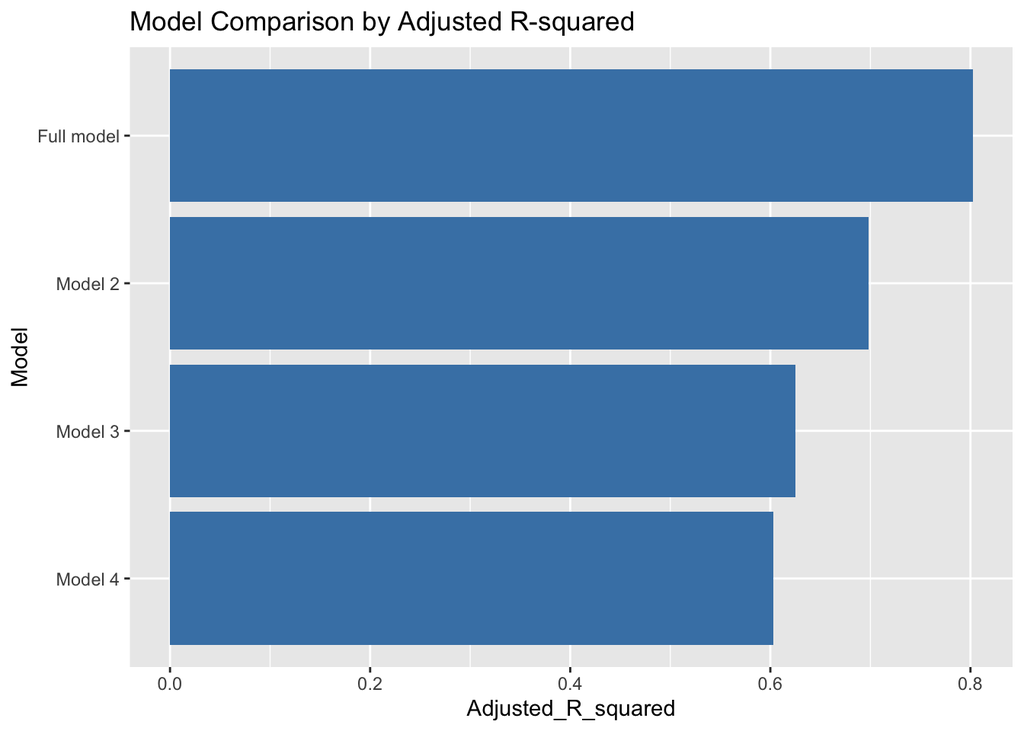

```r
# Create comparison chart
model_names <- c("Full model", "Model 2", "Model 3", "Model 4")
adj_r_squared <- c(summary(initial_model)$adj.r.squared,
                   summary(model2)$adj.r.squared,
                   summary(model3)$adj.r.squared,
                   summary(model4)$adj.r.squared)

model_comparison <- data.frame(Model = model_names, Adjusted_R_squared = adj_r_squared)
ggplot(model_comparison, aes(x = reorder(Model, Adjusted_R_squared), y = Adjusted_R_squared)) +
  geom_col(fill = "steelblue") +
  coord_flip() +
  labs(title = "Model Comparison by Adjusted R-squared",
       x = "Model")
```

## Task 4: Using the Model (3 points)

Without using the words “multiple regression model”, describe how you could use this analysis to cover an election or voter participation story.

The analysis points to a few counties worth calling first. Baltimore City and Prince George’s County sit well below the turnout rates their income and education levels would predict, which is a story about something structural that the demographic variables aren’t capturing. That gap between predicted and actual turnout is where I’d start reporting.

The age relationship also gives me a frame: Maryland’s oldest-skewing counties, places like Talbot and Kent, are consistently outperforming the rest of the state. I’d want to know whether that’s older residents voting at higher rates or something about how those communities are organized. Those are two very different stories. My first calls would be to local election administrators in both the high-performing and the underperforming counties to find out what, if anything, they’re actually doing differently.